# Base model

Shen Cheng

2026-02-05

## Components of a nonlinear mixed-effect model (NLME)

$$Y_{ij} = f(\theta_{i}, U_i, t_{ij}) + \epsilon_{ij} \\
\theta_{i} = d(\color{red}{\hat{\theta}}, COV_i, \eta_i) \\
\eta_i \sim N(0, \color{red}{\omega^2}) \\
\epsilon_ij \sim N(0, \color{red}{\sigma^2})$$
<sup>1</sup>

- Fixed-effect parameters ($\hat{\theta}$)
  - Structural model: $\hat{\theta}$ associated with structural components
    - typical values of CL: $TVCL=THETA(1)$
  - Covariate model: $\hat{\theta}$ associated with $COV_i$
    - Age effect on CL: $CL=TVCL+(AGE/30)**THETA(2)$
- Random effect parameters
  - Between subject/occasion variability (BSV/BOV, $\omega^2$)
    - AKA. Inter-individual/occasion variability (IIV/IOV)
  - Residual unexplained variability (RUV, $\sigma^2$)
    - AKA. Residual vairability (RV)
[^1]: Where $f()$ represents structural model; $d()$ represents individual parameter model that relates an individual’s parameters ($\theta_i$) to population typical values ($\hat{\theta}$) and subject characteristics ($COV_i$); $U_i$ represents designing components (e.g., dose, dosing intervals, and sampling time); $COV_i$ represents individual covariates (e.g., age in years, weight in kg, etc).

## What is a base model?

- Models with **no covariates**
- Only have $\hat{\theta}$ associated with structural model
  - $TVCL = THETA(1)$
    - All individuals will have the same average value for CL
- Doesn’t necessarily mean the model is simple
  - Complex structural model
  - Complex BSV/BOV structure

## Structural models

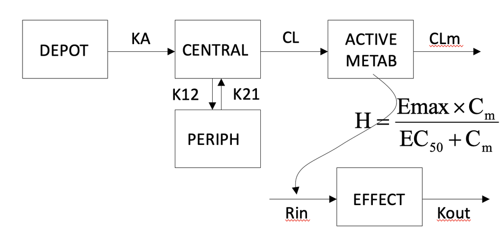

## Structural models

- Explicit, closed form solutions
  - Faster
  - Easier to implement for simple and familiar model
  - One-, two-, and three-compartment models with IV and extravascular dosing are NONMEM built in (ADVANs 1-4, 10-12)

$$C_{pred, t} = \frac{Dose}{V} \times e^{-K \times t}$$

- Differential equations
  - Slower
  - Easier to write differential equations for complex models (ADVANs 6, 8, 9, 13-15, $DES)

$$\frac{dX}{dt} = -K \times X \\
C_{pred, t} = \frac{X_t}{V}$$

## BSV

$$Y_{ij} = f(\theta_{i}, U_i, t_{ij}) + \epsilon_{ij} \\
\theta_{i} = d(\color{red}{\hat{\theta}}, COV_i, \eta_i) \\
\eta_i \sim N(0, \color{red}{\omega^2}) \\
\epsilon_ij \sim N(0, \color{red}{\sigma^2})$$

- NONMEM estimates the magnitude of the variance of a parameter in the population.
- Output is $\omega^2$: the variance of $\eta_i$ distribution.
  - Although $\eta_i$ will also be estimated, it is not considered as population parameters.
- In NONMEM, to specify a MODEL for BSV, we write it in terms of ETA, and say OMEGA ($\omega$) is the standard deviation of the ETAs ($\omega^2$ is variance).
  - $CL = TVCL + ETA(1)$
  - $V = TVV*EXP(ETA(2))$
- One ETA value per subject (based on the ID column in the NONMEM data set).

## CV% calculations in exponential model

- $\sqrt{\omega^{2}} \times 100\%$ is an approximation.
- Exact calculation: $\sqrt{e^{\omega^2}-1}$.

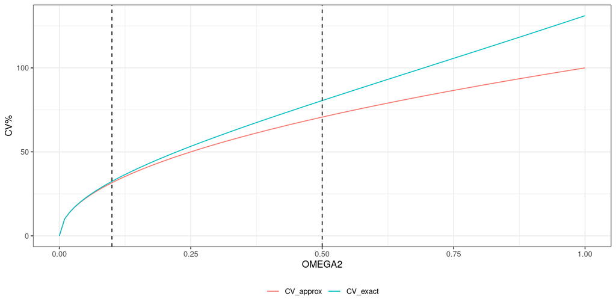

```r
data <- data.frame(`OMEGA2`=seq(0, 1, 0.01)) %>%
  mutate(`CV_approx` = sqrt(`OMEGA2`)*100,
         `CV_exact`  = sqrt(exp(`OMEGA2`)-1)*100) %>%
  pivot_longer(cols = starts_with("CV"), names_to = "name", values_to = "CV%")

ggplot(data, aes(x=`OMEGA2`, y=`CV%`, group=name, color=name))+geom_line()+
  geom_vline(aes(xintercept=0.1), linetype=2)+
  geom_vline(aes(xintercept=0.5), linetype=2)+
  theme(legend.position = "bottom", legend.title = element_blank())
```

## RUV

$$Y_{ij} = f(\theta_{i}, U_i, t_{ij}) + \epsilon_{ij} \\
\theta_{i} = d(\color{red}{\hat{\theta}}, COV_i, \eta_i) \\
\eta_i \sim N(0, \color{red}{\omega^2}) \\
\epsilon_ij \sim N(0, \color{red}{\sigma^2})$$

- NONMEM estimates the magnitude of the variance of a parameter in the population.
- RUV is the variability in the prediction errors after the other models are included.
- Output population parameter is $\sigma^2$: the variance of $\epsilon_{ij}$ distribution.
  - Although $\epsilon_{ij}$ will also be estimated, it is not considered as population parameters.
- In NONMEM, to specify a MODEL for RUV, we write it in terms of EPS/ERR, and say SIGMA ($\sigma$) is the standard deviation of the EPS/ERR ($\sigma^2$ is variance).
- One EPS value per observation.

## RUV

- A couple of main choices:
  - Additive error model
  - Proportional error model
  - Combined error model

## Additive error model

$Y = IPRED + EPS(1)$<sup>1</sup>

- SIGMA is the variability, usually reported as the SD across all concentrations.
  - Constant SD for all concentrations
    - For example: An observation with 10 mg/L concentration has the same absolute residual error compared to one with 1 mg/L concentration.
  - If $SIGMA(1)^2 = 5.29$, SD is 2.3 mg/L ($\sqrt{5.29}=2.3$)
- May be appropriate with concentrations over a limited range, such as TDM data
[^2]: Where Y represents observations; IPRED represents individual predictions; EPS(1) represents individual residual errors (one per observations).

## Proportional error model

$Y = IPRED*(1 + EPS(1))$<sup>1</sup>

- SIGMA is the variability, usually reported as the % coefficient of variations (CV%) across all concentrations.
  - Noise is proportional to the signal (Constant CV)
    - For example: An observation with 10 mg/L concentration has proportionally higher absolute residual error than one with 1 mg/L concentration.
  - If $SIGMA(1)^2 = 0.0234$, CV% is 15.3% ($\sqrt{0.0234}=0.153$)
- Commonly used in PK modeling.
[^3]: Where Y represents observations; IPRED represents individual predictions; EPS(1) represents individual residual errors (one per observations).

## Combined error model

$Y = IPRED*(1 + EPS(1)) + EPS(2)$<sup>1</sup>

- Have both proportional and addItive components.
- At low concentrations:
  - $IPRED*EPS(1)$ is insignificant.
  - $EPS(2)$ is dominate.
- At high concentrations:
  - $IPRED*EPS(1)$ is dominate.
  - $EPS(2)$ is insignificant. - CV decreases and plateaus.
[^4]: Where Y represents observations; IPRED represents individual predictions; EPS(1) and EPS(2) represent individual proportional and additive residual errors, respectively (one per observations).

## Combined error model

```r
data <- data.frame(Concentration=seq(0.1, 5, 0.01)) %>%
  mutate(Y=Concentration*(1+0.1)+0.05,
         `CV%` = (Concentration*0.1+0.05)/Concentration*100)

ggplot(data, aes(x=Concentration, y=`CV%`))+geom_line()
```

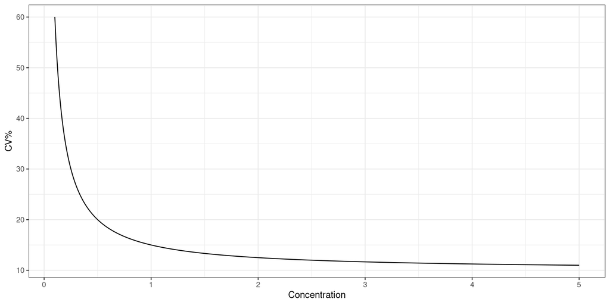

## Combined error model

Variance method (“combined 2” error model in Monolix):

```
...
$ERROR
...
Y = IPRED + IPRED*EPS(1) + EPS(2)
...

$OMEGA
0.01
0.01
```

```
...
$ERROR
...
W = SQRT((SD1*IPRED)**2 + SD2**2)
Y = IPRED + W*EPS(1)
...

$OMEGA
1 FIX
```

Standard deviation method: (“combined 1” error model in Monolix)

```
...
$ERROR
...
W = SD1*IPRED + SD2
Y = IPRED + W*EPS(1)
...

$OMEGA
1 FIX
```

## Difference between two combined error model<sup>1</sup>

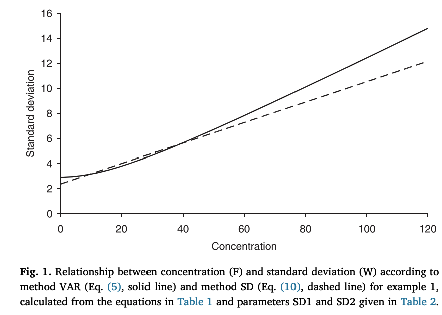

[^5]: Proost JH. (2017) *European Journal of Pharmaceutical Sciences*

## Writing a NONMEM control stream

- Name of data file; where does it live?
- Where are covariates in dataset?
- Which PK model (1cpt vs 2cpt vs …)?
- How is it parameterized (CL, V, K10, beta, …)?
- What are the covariate models?
- What are the BSV models?
- What is the RUV model?
- What are the initial parameter estimates?
- What do I want in output tables?

## Writing a NONMEM control stream

- NMTRAN Control Stream
- Text file (`.ctl` or `.mod`)
- All the instructions NONMEM needs to complete the run
- Control records
  - `$PROB`, `$PK`
  - Some required, some optional
  - Many options

## Example NONMEM control stream

```bash
$PROBLEM THEOPHYLLINE SINGLE SUBJECT DATA
$INPUT DOSE=AMT TIME CP=DV
$DATA DATA3
$SUBROUTINES ADVAN2
$PK
    KA=THETA(1)
    K=THETA(2)
    SC=THETA(3)
$ERROR
    Y=F+ERR(1)
$THETA
    (0,1.7)
    (0,.102)
    (0,29)
$ESTIMATION MAXEVAL=240 PRINT=2
$COVR
$TABLE TIME
```

## `$PROB`

- Same to `$PROBLEM`
- Specify the run number and any text you want to identify this particular run.
- `$PROB run001 BASE MODEL`
- `$PROB run002 test WT on CL`

## `$INPUT`

- Same to `$INPT`
- A list of labels to describe what’s in the data file, i.e., the column headings
- `$INPUT C ID TIME AMT DV SS II WT AGE HT PHTY GENO …`
- Some are required for NONMEM, others for PREDPP:
  - Reserved data items: `ID, L1, L2, DV, MDV, TIME, DATE`, etc
- **CAREFUL**: NONMEM will NOT match these labels to labels on the columns of the dataset
- Previously, labels limited to 4 characters; now 20
- Previously, limited to 20 data items; now 50
- Can use `HT=DROP` to drop or skip a column

## `$DATA`

- Name and path to your data file
- Usually a `.csv` file
- `IGNORE=C` (or `IGNORE=@`)
  - Optional; directs NMTRAN to ignore any row in the data set that has a C (or any character) in the first column
  - Allows you to NOT physically delete the record
  - Useful for missing data, BQL, ignoring outliers
  - Useful for analyzing a subset of dataset
- `$DATA moxidata.csv IGNORE=C`

| C | ID | TIME | DV |
| --- | --- | --- | --- |
| . | 1 | 12 | 12 |
| . | 1 | 123 | 123 |
| C | 1 | 124 | 1 |

## `$SUBROUTINES`

- Same to `$SUB`
- This is where you specify your PK model
  - ADVANx: compartmental model
  - TRANSx: choice of parameterization
- `$SUB ADVAN2 TRANS2`

## `ADVANx` can specify a pre-defined PK Model

- ADVAN1: 1-cpt IV
- ADVAN2: 1-cpt extravascular/IV
- ADVAN3: 2-cpt IV
- ADVAN4: 2-cpt extravascular/IV
- ADVAN10: 1-cpt with Michaelis-Menten elimination
- ADVAN11: 3-cpt IV
- ADVAN12: 3-cpt extravascular/IV

## `ADVANx` can specify a user-input ODE model

- General Nonlinear Model: ADVAN6, 8, 9, and 13-15, requires `$DES`
- General Linear Model: ADVAN5 and 7.

## `TRANSx` specifies the parameterization

- 1-cpt extravascular PK model
  - `ADVAN2 TRANS1`: K, V, and KA as parameters.
  - `ADVAN2 TRANS2`: CL, V, and KA as parameters.
- 2-cpt extravascular PK model
  - `ADVAN4 TRANS4`: CL, V2, Q, V3, and KA as parameters.
  - `ADVAN4 TRANS1`: K23, K32, K, V2, and KA as parameters.
  - `TRANS3`, `TRANS5` and `TRANS6`.

## `$PK`

- The fun part!
- Where you build your population model.
- Depending on your choice of ADVAN and TRANS, certain variable names will be required (more later).
- `$PK` calculates the predicted DV under the model.
- NONMEM is moving mass of drug through the compartments, however, we usually measure concentration.
- `$PK` is computing the predicted “scaled drug amount” (scaling factors: `S1`, `S2`, `SC`, etc).

## `$PK` example

```bash
$PK
TVCL=THETA(1) + THETA(2)*WT
   CL=TVCL*EXP(ETA(1))
TVV=THETA(2)
   V=TVV*EXP(ETA(2))
SC=V
```

## `$ERROR`

- This is where you build your Residual Unexplained Variability (RUV) model
- `$PK` calculates the predicted value and passes it on to `$ERROR` in the variable named F
- `$ERROR` can modify the prediction, and can be used to define a PD relationship, say, convert Cp to E through a PD model

## `$ERROR` example

```bash
$ERROR
IPRED = F
Y = IPRED*(1+EPS(1))
```

```bash
$ERROR
IPRED = A(2)/V2
Y = IPRED*(1+EPS(1))+EPS(2)
```

## `$THETA`

- Initial estimates of each THETA
- Can also include lower and upper bounds
- Must have an initial estimate for every THETA

```bash
$THETA
   (0,10,)      ;CL     [lower, initial, +inf]
   (0,34,70)    ;V      [lower, initial, upper]
   (1.5 FIX)    ;Ka     [parameter fixed]
   (,-6,)       ;THETAx [-inf, -6, +inf]
   (-4)         ;THETAx [-inf, -4, +inf]
   (,-5,0)      ;THETAx [-inf, -5, upper]
```

## `$OMEGA`

- Initial estimates for BSV
- A reasonable first guess is that the CV of a parameter is about 30%
  - 0.3 x 0.3 = 0.09
- Don’t include bounds

```bash
$OMEGA
    0.1   ; about 30% BSV on CL
    0.1   ; about 30% BSV on V
```

## `$OMEGA`

- Can have more than one `$OMEGA`
- Can incorporate off-diagonal elements (block matrices) to characterize covariance/correlations among BSVs.

```bash
$OMEGA BLOCK(2) ; VARIANCE COVARIANCE BLOCK(2)
 0.64           ; CL
 -0.24 0.58     ; V

$OMEGA
  0.1           ; KA
```

## `$SIGMA`

- Initial estimates for RUV
- Assuming a proportional error model, a reasonable first guess is that the CV of concentration predictions (e.g., PK) is about 10%
  - 0.1 x 0.1 = 0.01
- Don’t include bounds

```bash
$SIGMA
    0.01    ; about 10% RUV proportional error
```

## `$ESTIMATION`

- Same to `$EST`.
- LOTS of options specific to the estimation procedure.
- `$EST METHOD=1 INTERACTION MAXEVAL=9999 NSIG=3 SIGL=9 PRINT=1 MSF=./001.msf`
  - An example `$EST` using First-Order Conditional Estimation with $\eta$-$\epsilon$ Interactions (FOCE+I).
- And a whole lot more – don’t worry about them now.

## `COVARIANCE`

- Same to `$COV`.
- Directs NONMEM to compute the covariance matrix.
- Source of asymptotic standard errors.
- `PRINT=E`, request eigenvalues (for condition number calculation).

`$COV PRINT=E`

## `$TABLE`

- Specify to request NONMEM output for post-processing.
  - Several may be requested.
  - By default, table is printed in final NONMEM output report (`.lst`), use `NOPRINT` to waive this.
  - By default, append `DV PRED RES WRES` to each output table, use `NOAPPEND` to waive this.
  - `ONEHEADER`: only the first segment of each table has a header.
  - `FIRSTONLY`: only information corresponding to the first data record from each individual record appears in the table.

```bash
$TABLE NUM ID TIME DV MDV EVID IPRED NPDE CWRES NOPRINT ONEHEADER FILE=sdtab1        ; Model predictions and residuals
$TABLE NUM ID CL V  KA ETAS(1:LAST) NOAPPEND NOPRINT ONEHEADER FIRSTONLY FILE=patab1 ; Model parameters
$TABLE NUM ID SEX GENO NOAPPEND ONEHEADER NOPRINT FILE=catab1                        ; Categorical covariates
$TABLE NUM ID AGE ALB SCR WT HT BSA EGFR DOSE NOAPPEND ONEHEADER NOPRINT FILE=cotab1 ; Continuous covariates
```

## `$TABLE`

- Finch Studio has rules for table output names, for the full use of its functionality<sup>1</sup>.

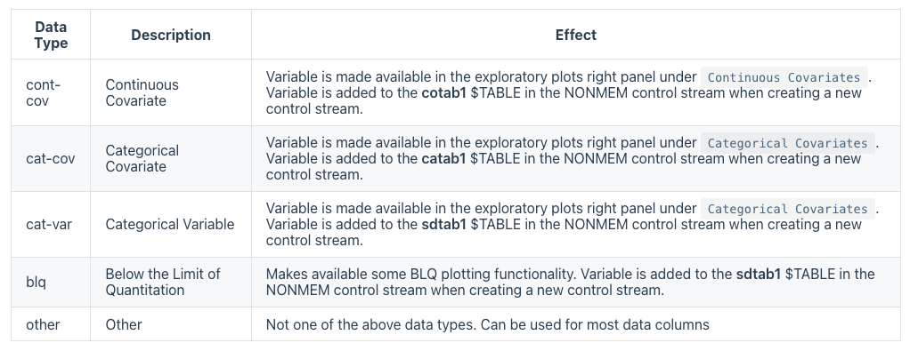

[^6]: https://docs.finchstudio.io/data/#mapping-your-data

## Finch Studio directory structure

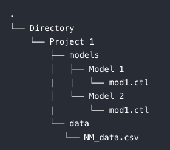

- “Convention over configuration”<sup>1</sup>
  - All projects must have the same file structure conventions.
  - Any name for `Directory` and `Project n` (e.g., `Directory` may be compound-specific, `Project n` may be a specific analysis).
  - All project sub-directory must have `models` and `data` folders.
  - Any name for `NM_data.csv`
  - All model controls streams must have a file name of `mod1.ctl`.
    - A suffix of 1 to make projects more compatible with post-processing tools such as `Xpose`.
[^7]: https://docs.finchstudio.io/installation/getting-started.html#directory-structure

## Useful references

- Finch Studio Directory Structure: https://docs.finchstudio.io/installation/getting-started.html#directory-structure
- pkpd-info.com: https://pkpd-info.com/NONMEM/Model_templates.php